# Session Eight - Plotting in Base R

By Hellen Gakuruh

January 18, 2017

## Session Goal

The main goal of this session is to introduce you to R’s plotting capabilities.

## What we shall cover

By the end of this session you should:

- Understand the basics of plotting in R
- Be capable of calling and changing graphical parameters
- Be skilled in annotating plots
- Have capacity to produce different base R plots
- Know how to use and create colors in base R
- Be acquainted with R’s graphical devices

## Prerequisite

To appreciate this session, you must be conversant with:

- Making function calls
- Subsetting data objects

Some understanding of these would be good though definitions are given within text and additional notes will be given.

- Object Oriented Programming in R, particularly concept of classes and generic functions (draft notes on this has been shared)
- Looping in R (especially “sapply”, “lapply” and “by()”)

## Introduction

Communicating outputs is the epitome of data analysis and one way to do it is through plots. Base R provides numerous plotting functions which produce some of the well known data display. To understand these functions and in deed many other plotting functions that come with add-on packages, you only need to learn one function, that is “plot()”.

In this regard, we shall begin this session by appreciating base R’s “plot” function as a guide to other plotting functions. It is anticipated that this understanding will enable you to not only make good plots but also comprehend and rectify errors as need be.

**Pre-session**

Installing and loading required packages

```r
# Require package reshape2 for a data set called tips
if (!"reshape2" %in% installed.packages()) {
  install.packages("reshape2", lib = .libPaths()[1])
}
library(reshape2)

# Require package ggplot2 for data set called economics
if (!"ggplot2" %in% installed.packages()) {
  installed.packages("reshape2", lib.loc = .libPaths()[1])
}
library(ggplot2)
```

## Understanding base R plotting function

The main plotting function in base R is “plot()”, a S3 generic function. Generic functions are used to dispatch other functions called (methods). To understand generic functions, see them as tool boxes containing related tools. The work of these tool boxes (generic functions) is to give you an appropriate tool given a request. In this analogy, tools are methods defined to work on certain classed objects. Request can be viewed as first argument to a generic function. For tool box (a generic function) to give you a tool (method) your request (object) must first be classed or have a class attribute (we learnt this in session four), second, it’s class should be among those listed by methods. Listed by methods in the sense that there is a method for the given classed object. Let’s look as methods in plot() to grasp this.

All available methods in any given S3 generic can be shown with function “.S3method”.

```r
plotMethods <- .S3methods("plot")
plotMethods
##  [1] plot.acf*           plot.data.frame*    plot.decomposed.ts*
##  [4] plot.default        plot.dendrogram*    plot.density*
##  [7] plot.ecdf           plot.factor*        plot.formula*
## [10] plot.function       plot.ggplot*        plot.gtable*
## [13] plot.hclust*        plot.histogram*     plot.HoltWinters*
## [16] plot.isoreg*        plot.lm*            plot.medpolish*
## [19] plot.mlm*           plot.ppr*           plot.prcomp*
## [22] plot.princomp*      plot.profile.nls*   plot.raster*
## [25] plot.spec*          plot.stepfun        plot.stl*
## [28] plot.table*         plot.ts             plot.tskernel*
## [31] plot.TukeyHSD*
## see '?methods' for accessing help and source code
```

From output above, it is clear to see that plot has 31 methods, meaning plot can be called with 31 different objects.

S3 methods are in the form “genericname.class”, for example, for “plot.factor”, “plot” is the generic name while “factor” is class of objects expected when called. Usually we do not call methods directly as this is done by generic functions once they have identified an appropriate method. So in this case we would call plot() rather than plot.factor() or any other method it contains. It however does not mean a method can not be called directly, it can and it should work if correct class is selected, however, if future changes are made to methods in a generic, they will not be reflected in your code as you did not call generic.

With this soft landing on object oriented programming in R, let’s look at some of plot()’s output to understand its dispatching mechanism.

### Some outputs of plot()

```r
# All possible combinations of a data frame with three variables
variables <- c("X", "Y", "Z")
nrow(expand.grid(variables, variables))
## [1] 9
```

We will used base R’s data sets to see plots produced y different inputs to “plot()”

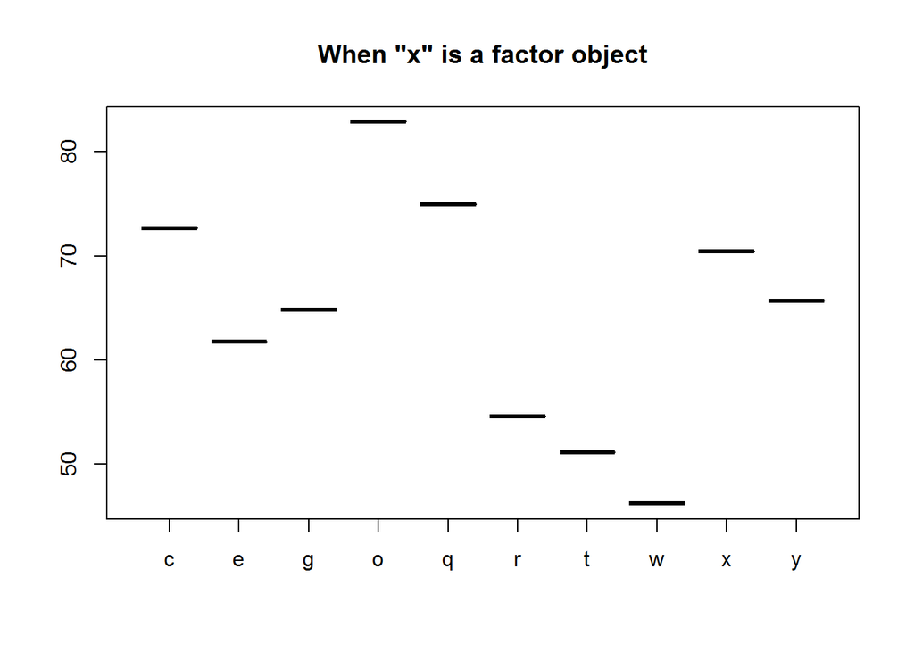

```r
# Data
#----------
set.seed(5839)
a <- factor(sample(letters, 10))
set.seed(84758)
b <- rnorm(10, 60, 10)
class(a)
## [1] "factor"
class(b)
## [1] "numeric"

# Passing individual vector (they must be of the same length)
#------------------------------------------------------------
# When x is a factor vector
plot(x = a, y = b, main = 'When "x" is a factor object')
```

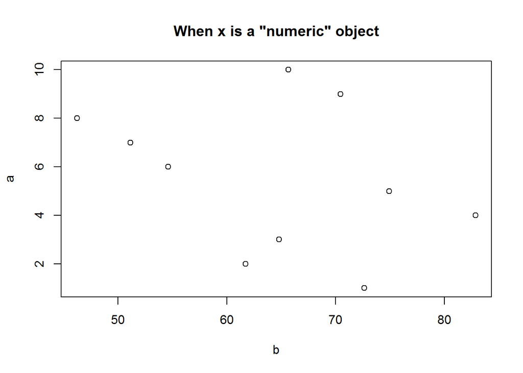

```r
# When x is a numeric vector
plot(x = b, y = a, main = 'When x is a "numeric" object')
```

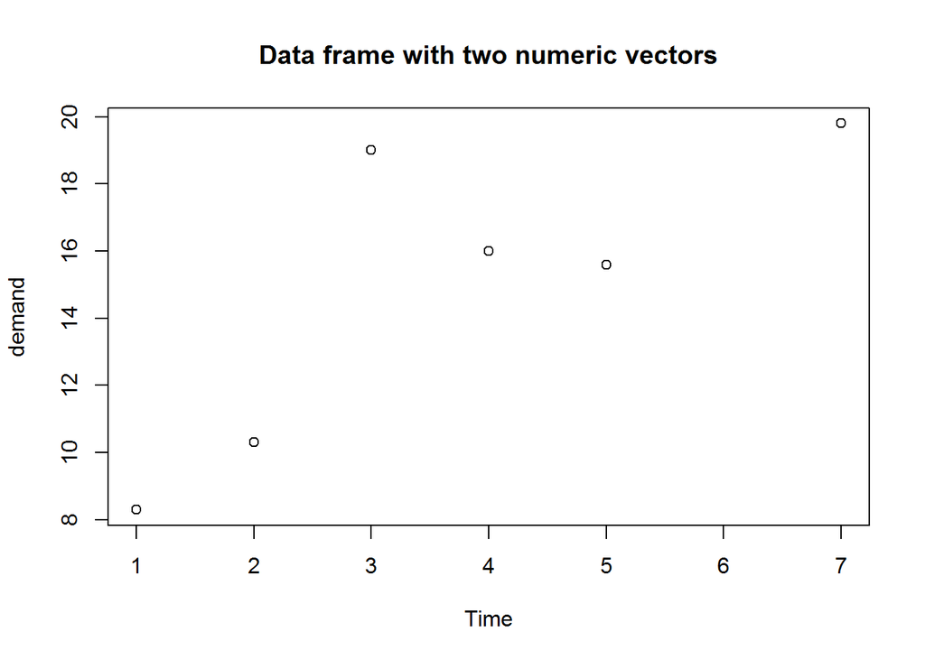

```r
# Passing a data frame object
#----------------------------
# Data frame with two numerical variables
sapply(BOD, class)
##      Time    demand
## "numeric" "numeric"
plot(BOD, main = "Data frame with two numeric vectors")
```

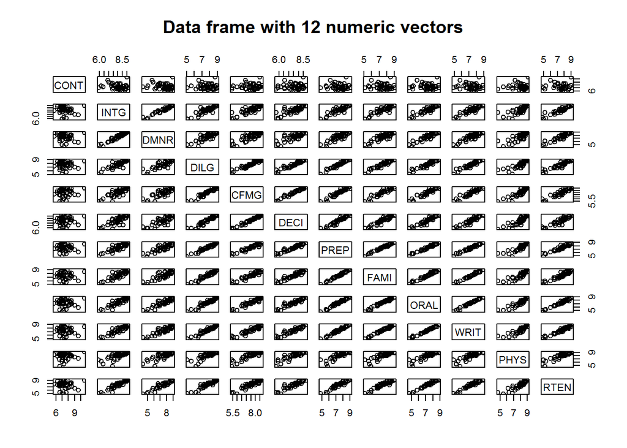

```r
# Data frame with 12 numerical variables
sapply(USJudgeRatings, class)
##      CONT      INTG      DMNR      DILG      CFMG      DECI      PREP
## "numeric" "numeric" "numeric" "numeric" "numeric" "numeric" "numeric"
##      FAMI      ORAL      WRIT      PHYS      RTEN
## "numeric" "numeric" "numeric" "numeric" "numeric"
plot(USJudgeRatings, main = "Data frame with 12 numeric vectors")
```

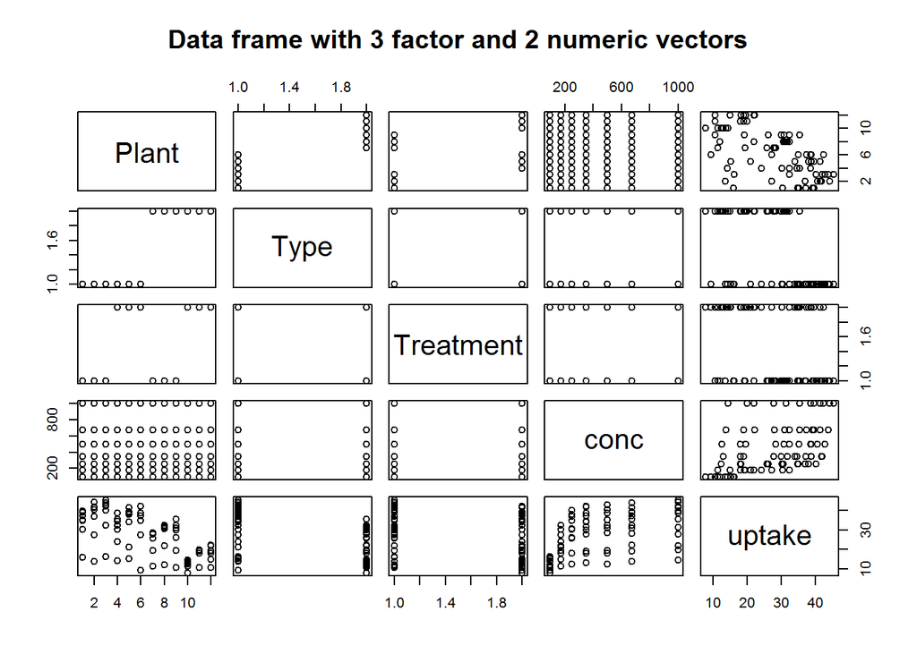

```r
# Data frame with 5 mixed factor and numerical variables
sapply(CO2, class)
## $Plant
## [1] "ordered" "factor"
##
## $Type
## [1] "factor"
##
## $Treatment
## [1] "factor"
##
## $conc
## [1] "numeric"
##
## $uptake
## [1] "numeric"
plot(CO2, main = "Data frame with 3 factor and 2 numeric vectors")
```

Clearly, it might be wise to avoid calling plot with a data frames multiple variables as they might not be fitted in the plotting window.

For time series objects, plot() will call “plot.ts()” which is basically a line plot, that is plot(type = “l”). For decomposed time series (we shall discuss this in level three), plot will call plot.decomposed.ts() which will output a plot of each decomposed component.

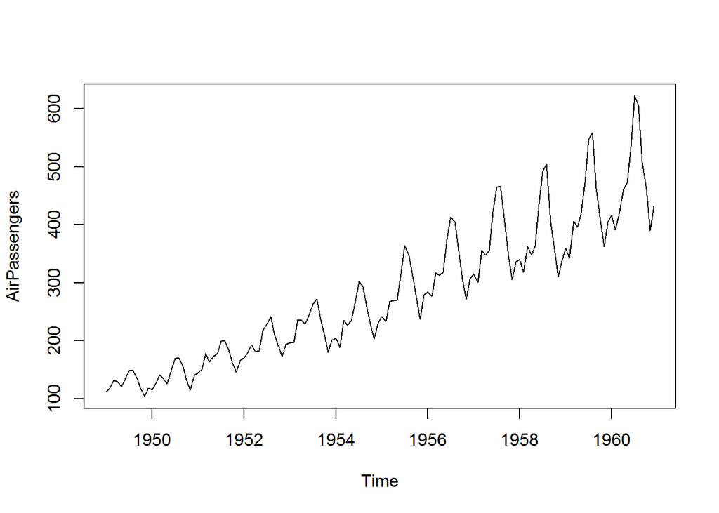

```r
class(AirPassengers)
## [1] "ts"
plot(AirPassengers)
```

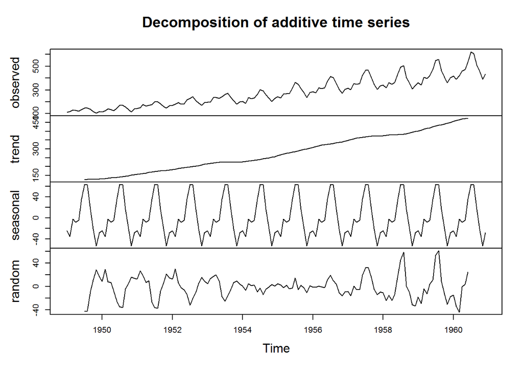

```r
# Decomposing a time series
decomposed <- decompose(AirPassengers)
plot(decomposed)
```

Factor vectors passed to plot() will produce bar plots.

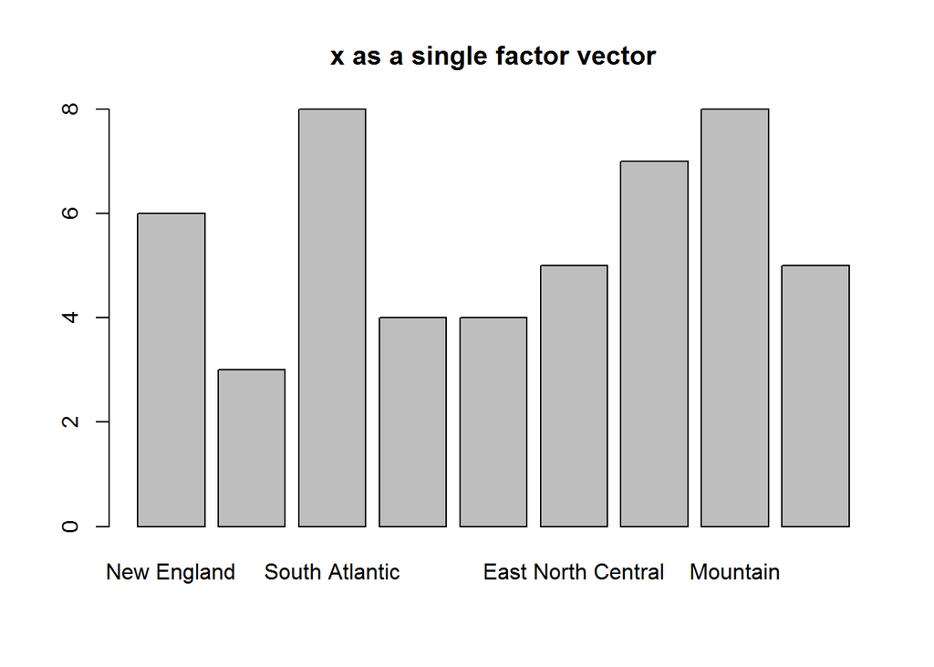

```r
class(state.division)
## [1] "factor"
plot(state.division, main = "x as a single factor vector")
```

Objects with class table produce mosaic plots

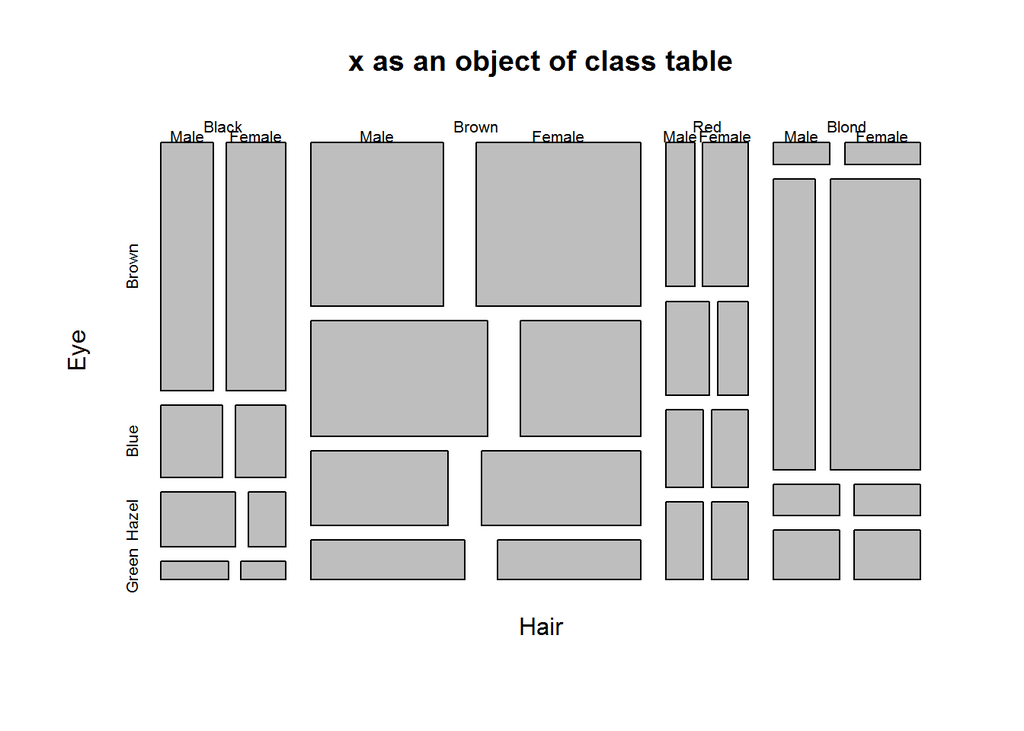

```r
class(HairEyeColor)
## [1] "table"
plot(HairEyeColor, main = "x as an object of class table")
```

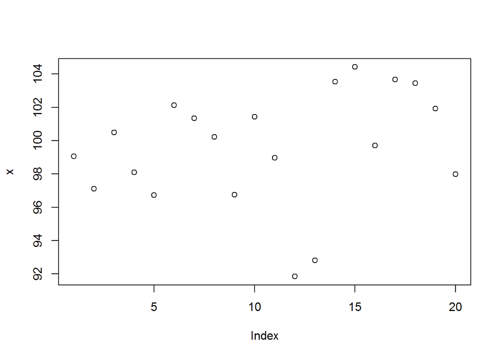

```r
# Creating a numerical object with random numbers
set.seed(5739)
x <- rnorm(20, 100, 5)
x
##  [1]  99.05938  97.11321 100.48537  98.08425  96.71877 102.12758 101.34598
##  [8] 100.22366  96.74103 101.43612  98.97586  91.84400  92.82112 103.52759
## [15] 104.41966  99.69488 103.67352 103.44173 101.91382  97.98014

# Checking for a method for objects classed numeric
class(x); grep(pattern = class(x), x = methods("plot"))
## [1] "numeric"
## integer(0)

# Calling plot()
plot(x)
```

For non-numerical objects for which plot() has no method, plot.default() will attempt to convert them to finite objects when computing axis limits, if coercion is not feasible, then an error will be issued with additional warning messages.

```r
plot(letters)
# Error in plot.window(..) : need finite 'xlim' values
# In addition: Warning messages:
# 1: In xy.coord(x, y, xlabel, ylabel, log) : NAs introduced by coercion
# 2: In min(x): no non-missing arguments to min; returning Inf
# 3: In max(x): no non-missing arguments to max; returning -Inf
```

From preceding discussion, it should now be clear that class of plot()’s first argument (x), will determine the plotting method to be selected. This (dispatched) method will then output a plot based on all arguments passed to plot. Hence, a method can output different plots based on the same data (objects passed to x and y) given different values for other arguments. To understand these differences as well as potential error points, it is important to understand how plot() works.

This will require us to go to plots internals.

### plot() Internals

To know how a function works means inspecting its definition. A function’s definition is its body which can be seen by calling the function without parenthesis.

```r
# "plots" function definition
plot
```

Plot’s function definition is not written in R, but the code is similar to R so here’s an R version.

```r
plotDefault <- function(x, y = NULL, type = "p", xlim = NULL, ylim = NULL, log = "", main = NULL, sub = NULL, xlab = NULL, ylab = NULL, ann = par("ann"), axes = TRUE, frame.plot = axes, panel.first = NULL, panel.last = NULL, asp = NA, ...){
  localAxis <- function(..., col, bg, pch, cex, lty, lwd) Axis(...)
  localBox  <- function(..., col, bg, pch, cex, lty, lwd) box(...)
  localWindow <- function(..., col, bg, pch, cex, lty, lwd) plot.window(...)
  localTitle <- function(..., col, bg, pch, cex, lty, lwd) title(...)
  xlabel <- if (!missing(x)) deparse(substitute(x))
  ylabel <- if (!missing(y)) deparse(substitute(y))
  xy <- xy.coords(x, y, xlabel, ylabel, log)
  xlab <- if (is.null(xlab)) {
    xy$xlab
    } else xlab
  ylab <- if (is.null(ylab)) {
    xy$ylab
  } else ylab
  xlim <- if (is.null(xlim)) {
    range(xy$x[is.finite(xy$x)])
    } else xlim
  ylim <- if (is.null(ylim)) {
    range(xy$y[is.finite(xy$y)])
  } else ylim
  dev.hold()
  on.exit(dev.flush())
  plot.new()
  localWindow(xlim, ylim, log, asp, ...)
  panel.first
  plot.xy(xy, type, ...)
  panel.last
  if (axes) {
    localAxis(if (is.null(y)) xy$x  else x, side = 1, ...)
    localAxis(if (is.null(y))    x  else y, side = 2, ...)
  }
  if (frame.plot)
    localBox(...)
  if (ann)
    localTitle(main = main, sub = sub, xlab = xlab, ylab = ylab, ...)
  invisible()
}
```

From this definition, there are roughly eight steps taken to output a basic plot. These are:

1. Open new plotting window
2. Set x and y coordinates
3. Evaluate and execute any pre-plot expressions
4. Make the actual plot
5. Evaluate and execute post-plot and pre-axis expressions
6. Add axis if required
7. Frame plot if needed
8. Annotate, and finally display plot

Let’s go through these step by step and link them to plot’s arguments with a purpose of understanding expected values and their implication on output generated.

### Step one: Opening new window

When plot is called, the first thing it does is call a low level function “plot.new()”. This function is responsible for opening a plotting window on the active device. There are no arguments to this function though its background color can be changed from default to another color using graphical paramenters which we will learn in the next section.

```r
# Opening graphing window
plot.new()
```

We can take this to be like a frame for our canvas.

### Step two: Setting plotting coordinates

With plotting window opened, plot() will specify actual plotting area on a Cartesian plane by calling “plot.window()”. By default, range (minimum and maximum values) of x and y are used otherwise these can be values passed to “xlim” and “ylim”. We can consider this our canvas.

Note, if only one value is passed to plot(), it will be taken as “x” and “y” will be created as a sequence of values from 1 up to length of “x” (index of x). Plot will then map “x” values on the y axis and “y” values (indices) on the x axis. In this case, “x limit” (xlim) will be minimum and maximum values of y and not x, while “y limit” (ylim) will minimum and maximum values of “x”. Otherwise, if both x and y values are given they will be mapped as usual.

```r
# Open a new graphical window
plot.new()
```

```r
# Default
range(x); round(range(x))
## [1]  91.8440 104.4197
## [1]  92 104
xlim <- range(1:length(x))
ylim <- range(x)
plot.window(xlim = xlim, ylim = ylim)
```

Don’t expect any output or visible action from “plot.window” as it invisibly creates the coordinate system.

But just to see what it does, we will display an empty plot and extend its limits.

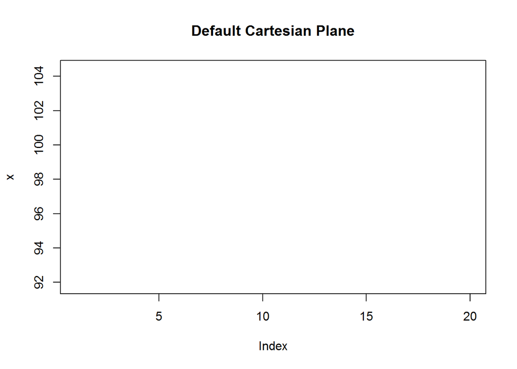

```r
# Plotting Area
plot(x, type = "n", main = "Default Cartesian Plane")
```

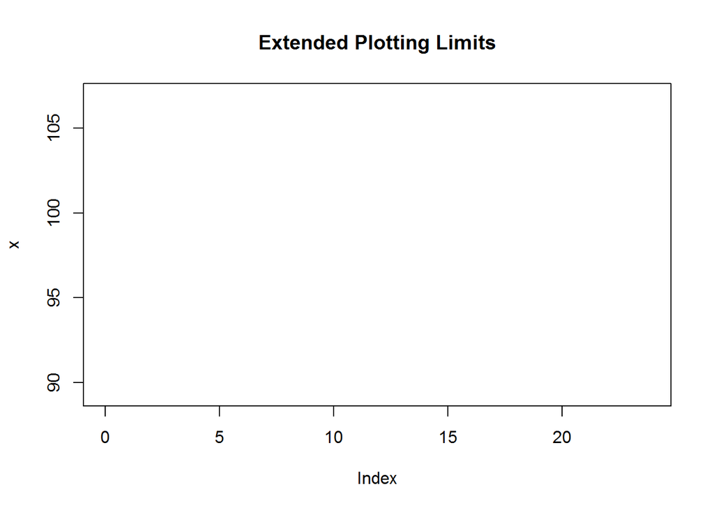

```r
# Plotting area with user defined limits (a bit of padding)
xlm <- extendrange(x, f = 0.2); round(xlm)
## [1]  89 107
ylm <- extendrange(1:length(x), f = 0.2); round(ylm)
## [1] -3 24
plot(x, type = "n", xlim = c(0, ylm[2]), ylim = xlm, main = "Extended Plotting Limits")
```

When incorrect limits are given to either “xlim” or “ylim”, an error will be issued indicating “plot.window()” is not able to construct the plane. For example, it is expected that x and y limits will be vectors of length two having minimum and maximum (range) values of x and y, if this is not so, execution stops with an error message.

```r
plot(x, xlim = 13, ylim = 4)
## Error in plot.window(...) : invalid 'xlim' value
```

Hope you notice a new plotting window was opened with “plot.new()” before issuing the error.

### Step three: Evaluate and execute pre-post functions

If there are certain actions to be done before a plot is generated they will be evaluated and executed. This is especially useful when actions to be done have an effect on data points or lines. For example, when adding grid lines or line of best fit, you would want to include this before data points to avoid plotting on top of the point.

Pre-plotting functions are passed to argument “panel.first” in plot.default. But to demonstrate how it is implemented, we are building our plot from our canvas.

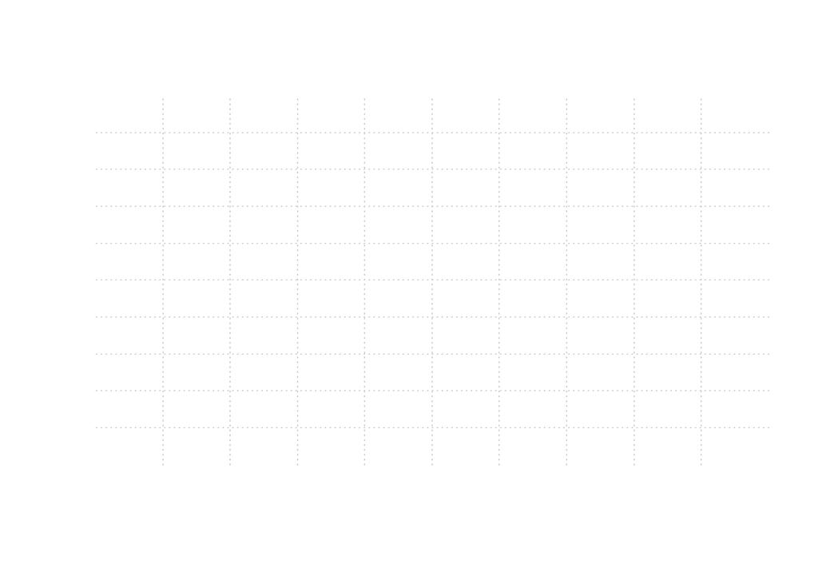

```r
plot.new()
plot.window(xlim = xlim, ylim = ylim)
grid(10)
```

since “plot.window” merely created our plotting area, what we have is a canvas with grid lines.

### Step four: Plotting

Before plotting, plot() calls “xy.coords” to generate x and y coordinates. xy.coord() is a low level standardizing function called by most of R’s high level plotting functions. Its core role is to ensure consistency in how x and y coordinates are generated. Output of this function is a list consisting of four elements; x and y coordinates plus x and y label (if given).

This is the function that generates sequence of numbers (1:length(x)) in the event y is not given.

```r
coords <- xy.coords(x)
coords
## $x
##  [1]  1  2  3  4  5  6  7  8  9 10 11 12 13 14 15 16 17 18 19 20
##
## $y
##  [1]  99.05938  97.11321 100.48537  98.08425  96.71877 102.12758 101.34598
##  [8] 100.22366  96.74103 101.43612  98.97586  91.84400  92.82112 103.52759
## [15] 104.41966  99.69488 103.67352 103.44173 101.91382  97.98014
##
## $xlab
## [1] "Index"
##
## $ylab
## NULL
```

With coordinates determined, plot() calls a another low level internal plotting function to do the actual plot, that is “plot.xy()” written internally in C language.

plot() calls plot.xy() function with output of xy.coords() and expected plot type, by default this is “p” for points. It also passes along the other values given during the call.

With grid lines set we can add point on top.

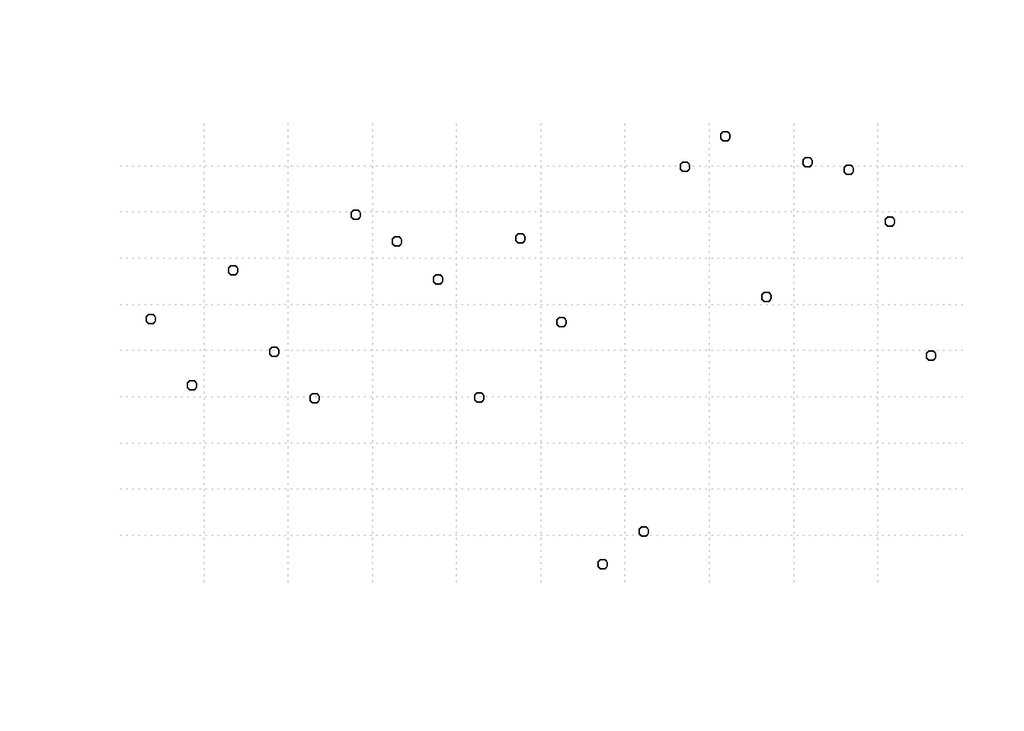

```r
plot.new()
plot.window(xlim = xlim, ylim = ylim)
grid(10)
plot.xy(coords, type = "p")
```

We have made significant progress, but as you can see, this plot does not have any axis, just grid lines and points. Axes are drawn after implementing any pre-axis expressions.

### Step five: Evaluation of post-plot and pre-axis expressions

Just like pre-plotting functions, “plot()” will look for functions passed to “panel.last” argument and evaluate them before constructing an axis.

Here let’s add a spline which is an interpolation line (we discuss this a bit later in this series, but in depth discussion will be during data analysis session).

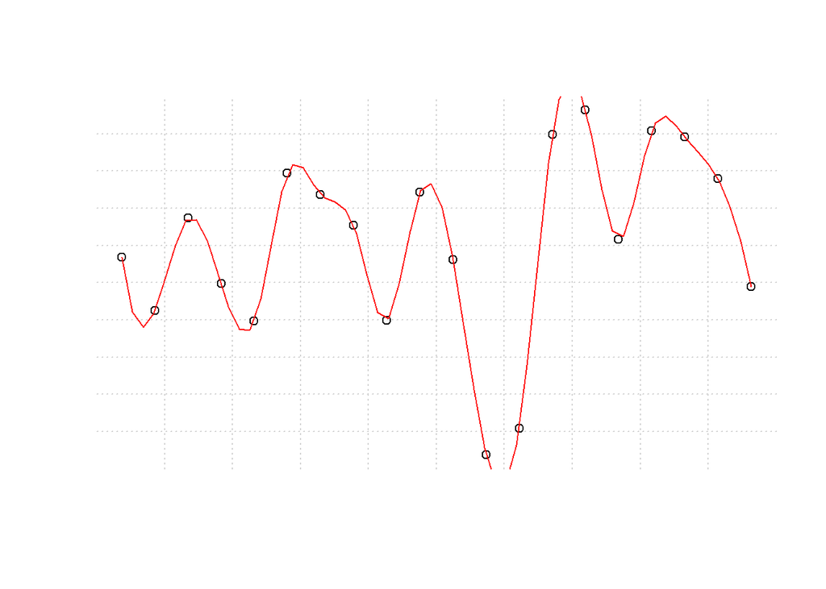

```r
plot.new()
plot.window(xlim = xlim, ylim = ylim)
grid(10)
plot.xy(coords, type = "p")
lines(spline(x), col = 2)
```

Notice grid lines are below data points while spline is on top of the data points. Also notice some tips (minimum and maximum) of the spline are clipped as they extend outside the canvas (plotting area); later we shall see some of the ways to rectify it.

### Step six: Construct Axis

After implementing post-plotting or pre-axis functions, plot will add axis at the bottom and left side of the plot. Tick marks are computed with a lower level function “axisTicks”, this function is called by “axis” function responsible for adding axis to plots. To generate labels for numerical axis, function “Axis” is called to generate appropriate labels before calling axis to draw them.

It might be useful to note the two similar function, “Axis” and “axis”. “Axis” is a generic function used mostly to develop axis labels for numerical data while “axis” is the main function used to draw axis on a plot. Hence in this case, plot() calls “Axis” as it will generate appropriate labels.

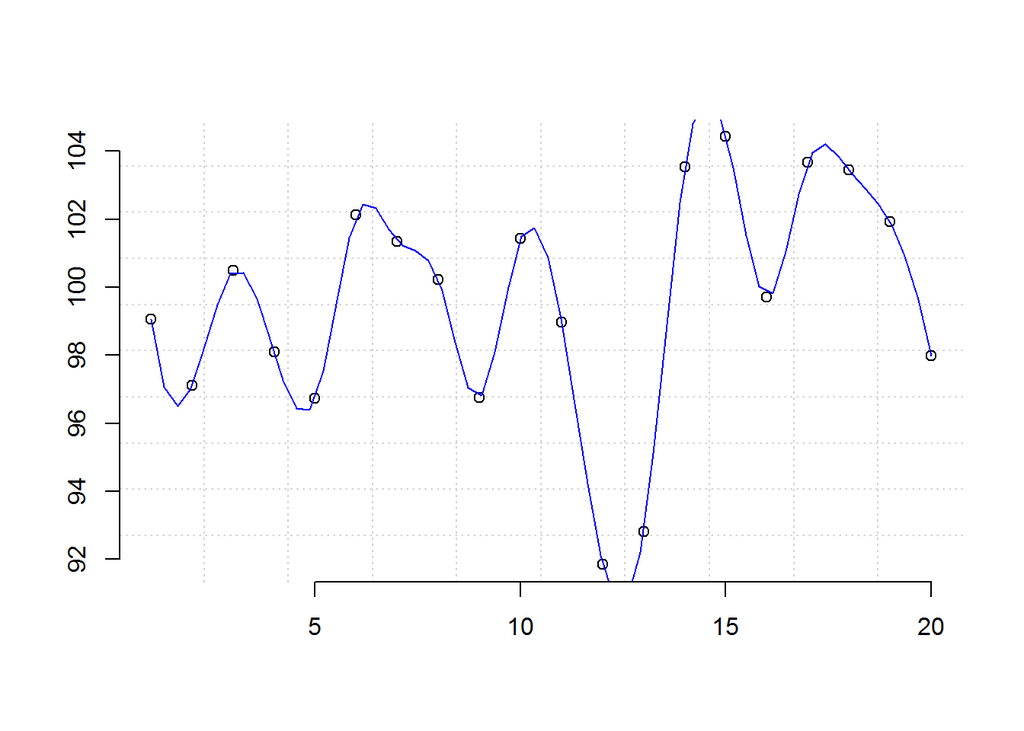

```r
plot.new()
plot.window(xlim = xlim, ylim = ylim)
grid(10)
plot.xy(coords, type = "p")
lines(spline(x), col = 4)

# Adding horizontal (x) axis
Axis(x, side = 1)

# Adding vertical (y) axis
Axis(x, side = 2)
```

### Step Seven: Ploting frame

Once axis are drawn, a frame is added to the plot by default although this can be suppressed by setting “frame.plot” argument to FALSE.

```r
plot.new()
plot.window(xlim = xlim, ylim = ylim)
grid(10)
plot.xy(coords, type = "p")
lines(spline(x), col = 2)
axis(1)
axis(2)

# Adding a frame
box()
```

[output not shown]

### Step Eight: Annotation

Finally the plot is annotated with axis labels. Default labels are extracted from the call to plot() (what is passed to “x” and “y”).

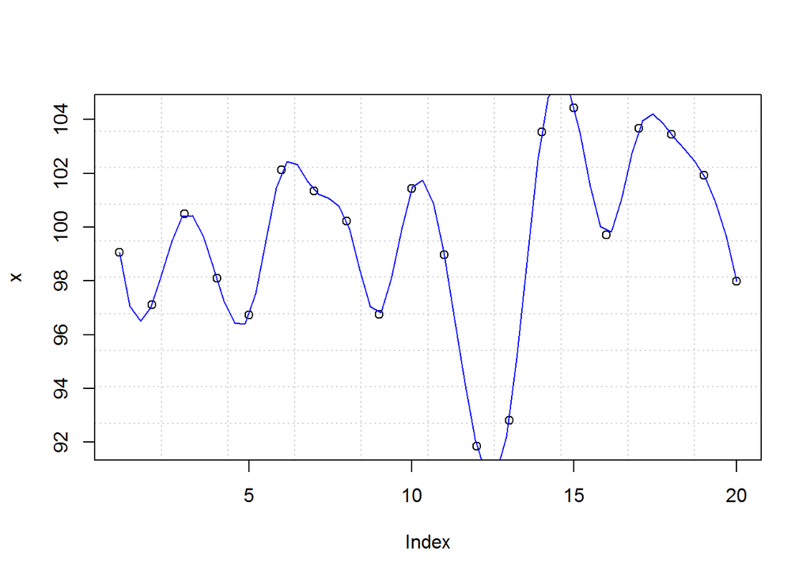

```r
plot.new()
plot.window(xlim = range(1:length(x)), ylim = range(x))
grid(10)
plot.xy(coords, type = "p")
lines(spline(x), col = 4)
axis(1)
axis(2)
box()

# Annotating with axis labels
title(xlab = "Index", ylab = "x")
```

### Summary: Final output

With that, you receive a basic plot. In summary these are the steps taken to produce this plot.

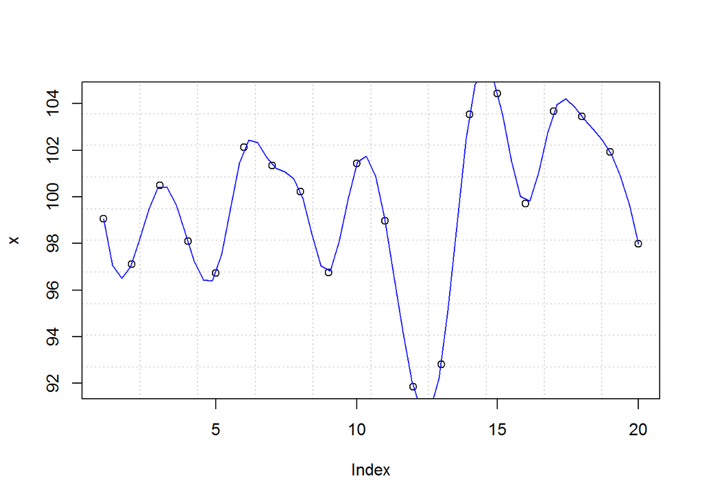

```r
# Step 1: Open new plotting window
plot.new()

# Step 2: Set up coordinate window (canvas)
plot.window(xlim = range(1:length(x)), ylim = range(x))

# Step 3: Evaluate and execute pre-plotting function
grid(10)

# Step 4: Call actual plotting function
plot.xy(xy.coords(x), type = "p")

# Step 5: Evaluate and implement post-plot and pre-axis functions
lines(spline(x), col = 4)

# Step 6: Add axis
axis(1)
axis(2)

# Step 7: Add a frame to plot
box()

# Step 8: Annotate with axis labels
title(xlab = "Index", ylab = "x")
```

You can generate an exact copy of this plot with `plot(x, panel.first = grid(10), panel.last = lines(spline(x), col = 4))`

### A commented basic plot definition

```r
source("~/R/Scripts/commentedPlotDefault.R")
```

Next we discuss how to improve output of a plot by changing graphical parameters.

## Graphical Parameters and Annotating Base R Plots

Output of base R’s default plot is as basic as it gets, however, R provides several graphical parameters and annotating functions for improving it. In this section we will go through some of base R’s graphical and annotation function as we try to make communicative plot.

### Querying, saving and resetting graphical parameters

In total, there are 72 graphical parameters which control a plot’s output.

```r
# Number of graphical parameters
length(par())
## [1] 72

# All graphical parameters
names(par())
##  [1] "xlog"      "ylog"      "adj"       "ann"       "ask"
##  [6] "bg"        "bty"       "cex"       "cex.axis"  "cex.lab"
## [11] "cex.main"  "cex.sub"   "cin"       "col"       "col.axis"
## [16] "col.lab"   "col.main"  "col.sub"   "cra"       "crt"
## [21] "csi"       "cxy"       "din"       "err"       "family"
## [26] "fg"        "fig"       "fin"       "font"      "font.axis"
## [31] "font.lab"  "font.main" "font.sub"  "lab"       "las"
## [36] "lend"      "lheight"   "ljoin"     "lmitre"    "lty"
## [41] "lwd"       "mai"       "mar"       "mex"       "mfcol"
## [46] "mfg"       "mfrow"     "mgp"       "mkh"       "new"
## [51] "oma"       "omd"       "omi"       "page"      "pch"
## [56] "pin"       "plt"       "ps"        "pty"       "smo"
## [61] "srt"       "tck"       "tcl"       "usr"       "xaxp"
## [66] "xaxs"      "xaxt"      "xpd"       "yaxp"      "yaxs"
## [71] "yaxt"      "ylbias"
```

All of these parameters have defaults values which can be queried with “par” function. Object returned will depend on number of graphical parameters queried.

```r
# Quering default value(s)
#-----------------------
# Quering one graphical parameter returns a vector
par("mar")
## [1] 5.1 4.1 4.1 2.1
class(par("mar"))
## [1] "numeric"

# Quering multiple graphical parameters returns a list
par("mfrow", "mar", "oma", "cex", "font")
## $mfrow
## [1] 1 1
##
## $mar
## [1] 5.1 4.1 4.1 2.1
##
## $oma
## [1] 0 0 0 0
##
## $cex
## [1] 1
##
## $font
## [1] 1
class(par("mfrow", "mar", "oma", "cex", "font"))
## [1] "list"
```

Default values can be saved and reset. Resetting to original parameters will be based on type of object save as having original values. If one value was save, then entire object can be used, otherwise if multiple parameters were were saved, then they would be in list form and usual list subsetting will be implemented.

```r
# Saving default values and resetting original parameter(s)
#----------------------------------------------------------
# Saving one parameter
op <- par("mar")
# Resetting using saved vector
par(mar = op)

# Saving multiple parameters
op <- par("mfrow", "mar", "oma", "cex", "font")
# Resetting using saved list
par(mfrow = op$mfrow, mar = op$mar, oma = op$oma, cex = op$cex, font = op$font)
```

### Setting/Changing graphical parameters

Out of the 72 parameters, 66 can be changed while 6 are read only (RO). Read only graphical parameters are, “cin”, “cra”, “csi”, “cxy”, “din”, and “page”.

When setting parameters using “par” function, it’s important to save original parameters and reset once plotting is complete.

As an example, let’s see how to make global and temporal changes for one and multiple graphical parameters.

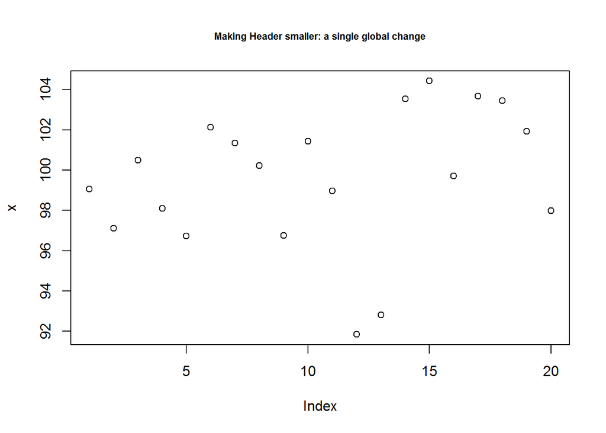

```r
# 1. Changing global parameters
#-------------------------------
# Save original parameter value
op <- par("cex.main")
# Set new parameter value
par(cex.main = 0.7)
# Generate a plot
plot(x, main = "Making Header smaller: a single global change")
```

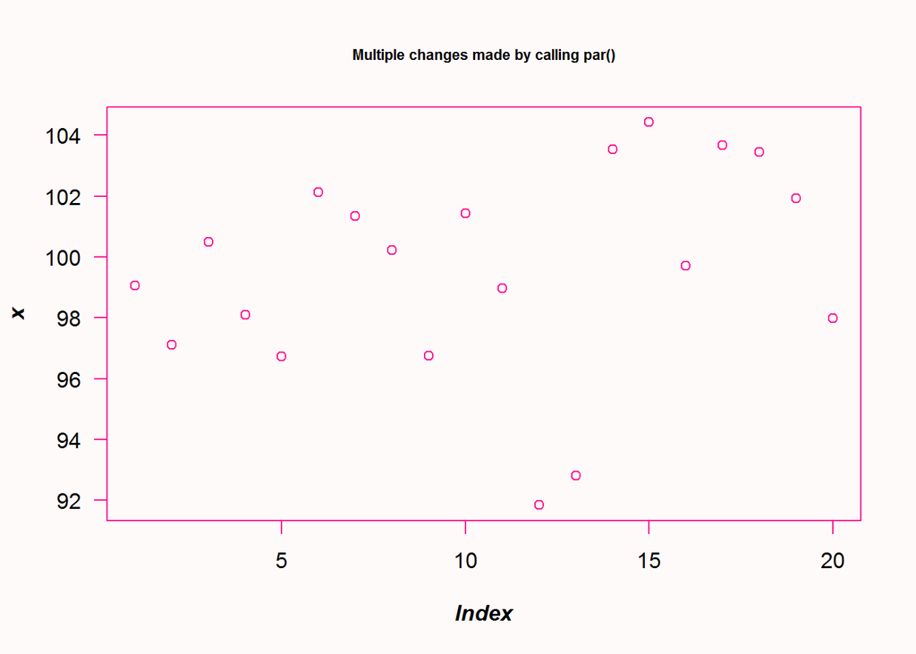

```r
# Reset original parameter
par(cex.main = op)

# Save multiple values of original parameter
op <- par("bg", "font.lab", "fg", "las", "cex.main")
# Set several parameters
par(bg = "snow", font.lab = 4, fg = "deeppink", las = 1, cex.main = 0.7)
# Generate plot
plot(x, main = 'Multiple changes made by calling par()')
```

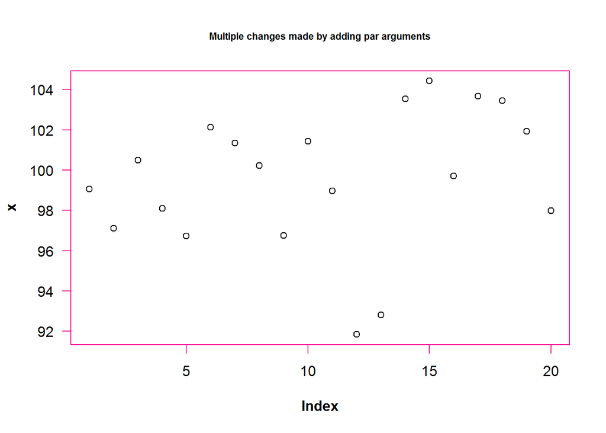

```r
# Reset original parameters
par(bg = op$bg, font.lab = op$font.lab, fg = op$fg, las = op$las, cex.main = op$cex.main)

# 2. Adding graphical parameters as arguments to plot, has a temporal effect
#---------------------------------------------------------------------------
plot(x, main = "Multiple changes made by adding par arguments", font.lab = 2, fg = "deeppink", las = 1, cex.main = 0.7)
```

### Implementing some graphical parameters and annotation

With knowledge on how to query, save, set and reset graphical parameters, let’s now explore a few more parameters to see how to drastically change a plot’s output.

In this small venture, we will see how to make multi-panel plots, use color, annotate with titles, reconstruct axis, use different plotting characters and add lines as informative displays (statistical lines) or for aesthetic.

#### Multi-paneling

Multiple plots can be displayed on the same window. R provides two graphical parameters to create multi-panel layout, these are “mfrow” and “mfcol”. “mfrow” creates multiple plots by row order while mfcol created layout by column order. Both of these parameters can only be set by calling “par” function.

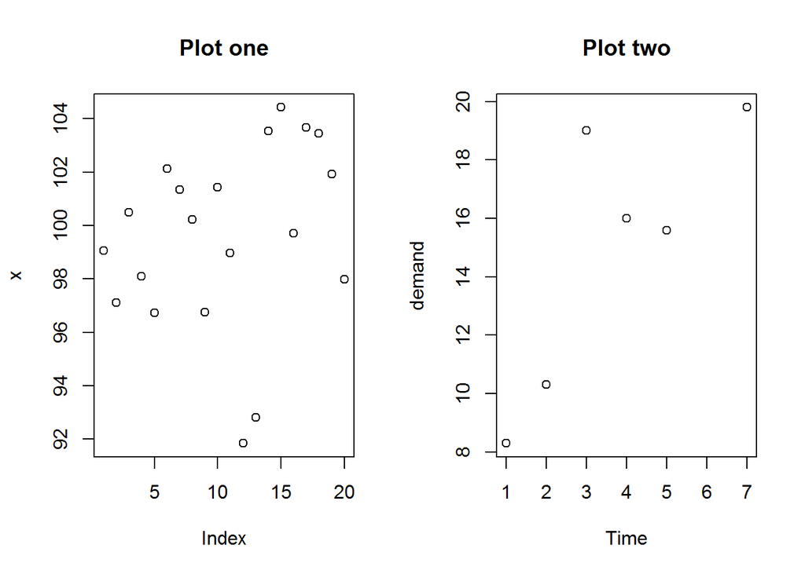

```r
# As good practice, querying and saving default values
op <- par("mfrow"); op
## [1] 1 1

# Implementing a row order layout
par(mfrow = c(1, 2))

# Making two plotting
plot(x, main = "Plot one")
plot(BOD, main = "Plot two")
```

```r
# Resetting original parameter
par(mfrow = op)

# Confirm restoration
par("mfrow")
## [1] 1 1
```

#### Annotating plots with titles and labels

There are three ways of annotating plots with titles and labels. The first involves calling a plotting function with titles and labels as arguments, the second is by calling “title” function and third is using “mtext” which adds these annotations as margin text.

##### Titles and labels as as arguments to plotting functions

The easiest way to add titles and labels to a plot is adding them as arguments when calling plot. These annotations can also be formatted by adding specific graphical parameters like color, size, type, and alignment.

As an example we are going to add a bold and slant main title, a grey, slant and smaller sub title, and a slant y label.

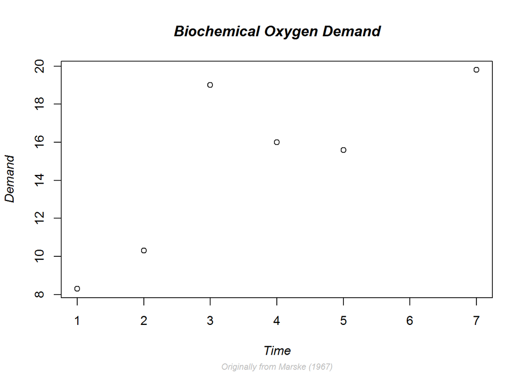

```r
# Annotating with titles and labels and formatting them
plot(BOD, main = "Biochemical Oxygen Demand", sub = "Originally from Marske (1967)", ylab = "Demand", font.main = 4, cex.sub = 0.7, col.sub = "grey", font.sub = 3, font.lab = 3)
```

Notice here we do not need to reset par() values as par() was not called directly.

##### Annotating with “title()”

Adding titles during call to plot has some restrictions especially where they are placed. For example, by default main title is place 3 lines from plotting region, this is somewhat far from plot especially more spaces is needed as the margins. Adding a line argument to a plotting function is not advisable as it corresponds to multiple other low level functions thereby can be effected by more functions than need be.

For this reason and others it might be good to call “title” function. This function gives more control on presenting and positioning.

Here we demonstrate layout or positioning of labels using function title and line argument.

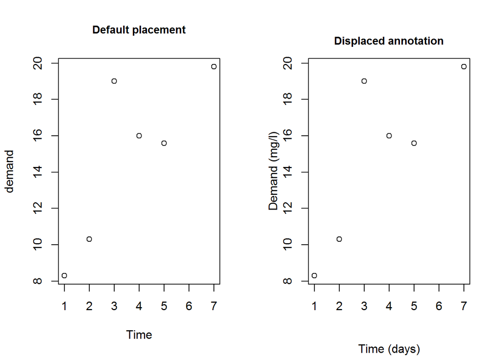

```r
# Making comparison (paneling)
par(mfrow = c(1, 2))

# Default plot
plot(BOD, main = "Default placement", cex.main = 0.9)

# Plotting with no annotation
plot(BOD, ann = FALSE)

# Moving x label further from x axis
title(xlab = "Time (days)", line = 4)

# Bring main title and y label closer to frame/axis
title(main = "Displaced annotation", line = 1, cex.main = 0.9)
title(ylab = "Demand (mg/l)", line = 2)
```

```r
# Resetting original parameters
par(mfrow = op)
```

##### Axis and graphical parameters

Graphical parameters can be used to construct different axis and axis labels. For example drawing an axis with slant labels. This is necessary when axis labels are long.

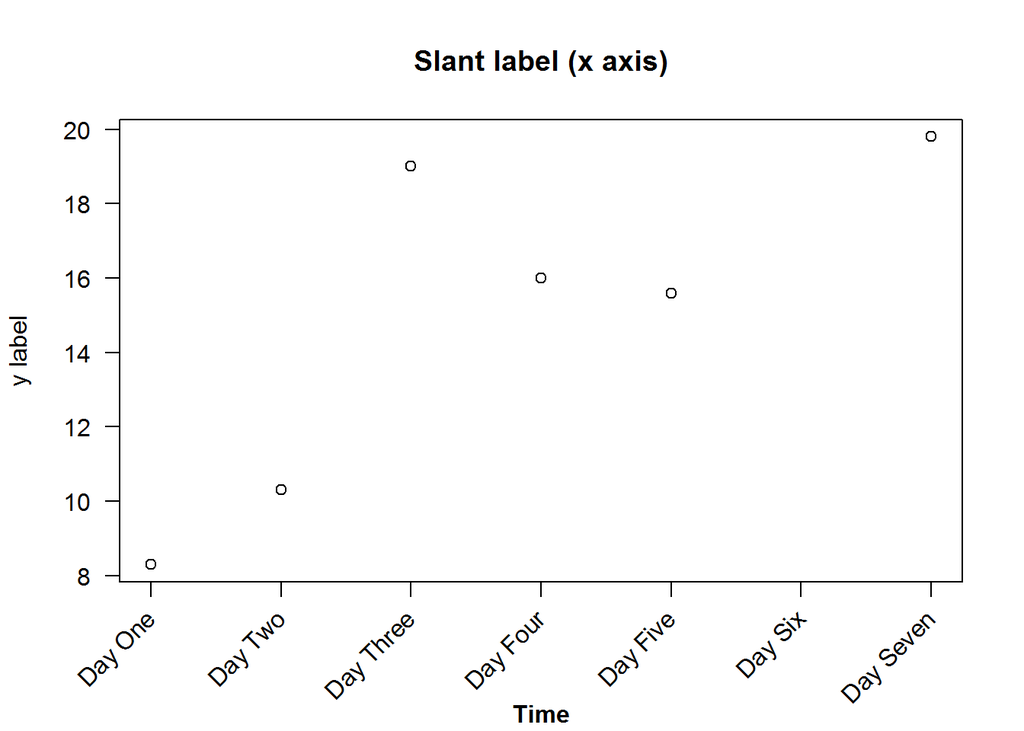

```r
# Labels for x axis
days <- paste("Day", c("One", "Two", "Three", "Four", "Five", "Six", "Seven"))

# Plotting but suppressing x axis and label
plot(BOD, xaxt = "n", las = 1, xlab = "", main = "Slant label (x axis)", ylab = "y label")

# Adding x axis without label
axis(side = 1, labels = FALSE)

# Adding labels as text to plot
text(1:length(days), par("usr")[3] - 0.9, srt = 45, adj = 1, labels = days, xpd = TRUE)

# Adding a bold x label some lines after axis label
mtext("Time", side = 1, line = 4, font = 2)
```

## Plotting characters (pch)

Plotting characters are symbols used to display data on a plot. These characters can be circles, squares, triangles, or stars. They can also be crossed, hollow, filled, big, or small. You can also use alphabetical letters, Greek and mathematical symbols.

Here are the first 25 symbols implemented by “S” and “R”.

```
##        x  y
##  [1,]  5 25
##  [2,] 10 25
##  [3,] 15 25
##  [4,] 20 25
##  [5,] 25 25
##  [6,]  5 20
##  [7,] 10 20
##  [8,] 15 20
##  [9,] 20 20
## [10,] 25 20
## [11,]  5 15
## [12,] 10 15
## [13,] 15 15
## [14,] 20 15
## [15,] 25 15
## [16,]  5 10
## [17,] 10 10
## [18,] 15 10
## [19,] 20 10
## [20,] 25 10
## [21,]  5  5
## [22,] 10  5
## [23,] 15  5
## [24,] 20  5
## [25,] 25  5
```

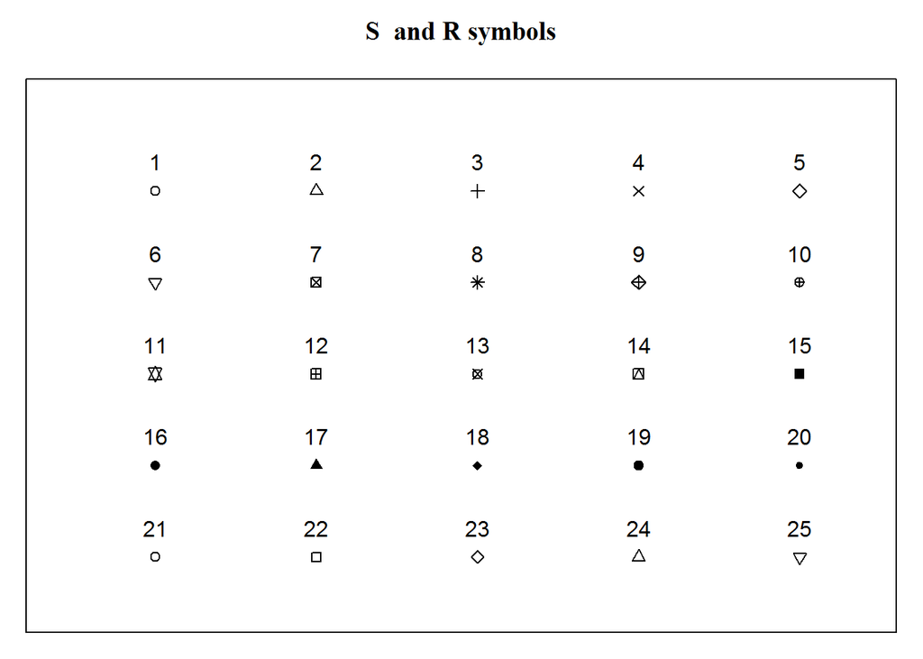

There are many more plotting characters, just have a look at R’s documentation on “points”.

## Plot types

There are two basic types of plots in base R’s plot(), “points” and “lines”, any other is a variations of these two. Actually, R can produce nine types of plots from lines and point, these are “l” for lines, “p” for points, “b” for both points and lines, “c” for empty points joined by lines, “o” for over plotted points and lines, “s” and “S” for stair steps and “h” for histogram-like vertical lines. There is also type “n” used to suppress plotting.

Let’s generate these plots, but this time being more efficient programmers. Instead of making nine calls to plot we will make two calls using a programming concept called “looping”. Essentially looping means “jump”, as in jump through some objects and perform a task. For example, in our case we have nine plots to generate, hence we want to “loop” over a counter from 1 through 9 and for each count, we want to make a plot, that is “plot 1”, “plot 2”, until “plot 9”. For each of these plots, we want to add an informative title i.e. type of plot.

When writing loops, you need to first determine aspects of the task that vary and those that are constant. In our case, tasks that vary (from one plot to the next) include, data sets as we will use two of them (BOD and tips[,1:2]), plot types and headings which will both have nine different sets. Tasks that will remain constant in all plots are x and y labels which we will suppress (to facilitate multi-plotting) and change y label’s orientation for legibility (par(“las”)). The idea behind looping is that varying tasks will be implemented with a subscript denoting index of task being carried out. Therefore these varying tasks will need to be indexed by creating vectors before calling a looping function.

As we will learn in level two, R has a number of looping functions each suitable for certain objects and/or tasks, here we will use “sapply”. Sapply takes an object to be looped as it’s first argument, and a function to be performed on each element of first argument as its second argument.

Basically, the first argument would consist of an object with two or more elements, like a list, a vector or a data frame (there other more suitable looping functions for matrices and array). In our case our first argument will be a vector with values 1 through 9 which will our counter (counting plots 1 to plot 9). Our second argument will be an anonymous function with one argument which an iterator. An iterator here is an index of plots to be generated and will be used to subset the varying arguments. Output of sapply is either a simplified vector or a list, in our case it produces an empty lists along side the plots, to generate plots without empty lists, we will suppress the list with function “invisible”.

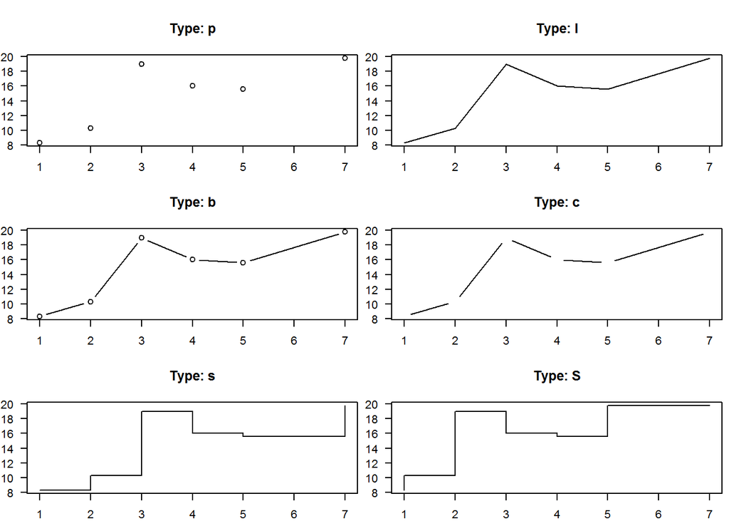

```r
# Querying, saving and changing original parameters
op <- par("mfrow", "mar")
par(mfrow = c(3,2), mar = c(2, 2, 4, 0.5))

# Extracting need vector from tips data
tips <- tips[, 1:2]

# Creating vectors of varing variables (elements to be subset)
dat <- c(rep("BOD", 7), rep("tips", 2))
type <- c("p", "l", "b", "c", "s", "S", "n", "o", "h")
main <- paste("Type:", type)

# Looping through a plot counter to construct nine different plots while suppressing returned empty list
invisible(sapply(seq_along(type), function(x) plot(get(dat[x]), type = type[x], main = main[x], xlab = "", ylab = "", las = 1)))
```

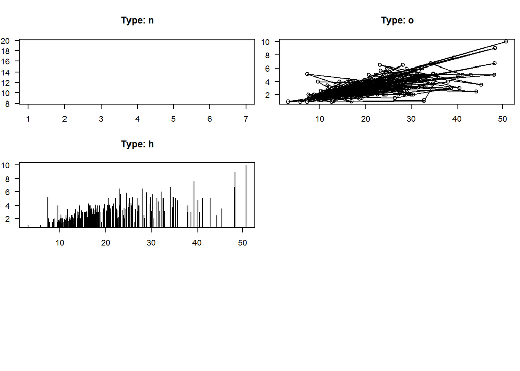

```r
# Resetting original parameters
par(mfrow = op$mfrow, mar = op$mar)
```

```r
# Try and produce these plots one at a time and see number of repetitive code used.
```

Looping is an interesting topic for which we get to learn from it’s foundation during our second level.

### Annotating plots with lines

Lines can be added to an existing plot either for statistical value or just plotting aesthetics.

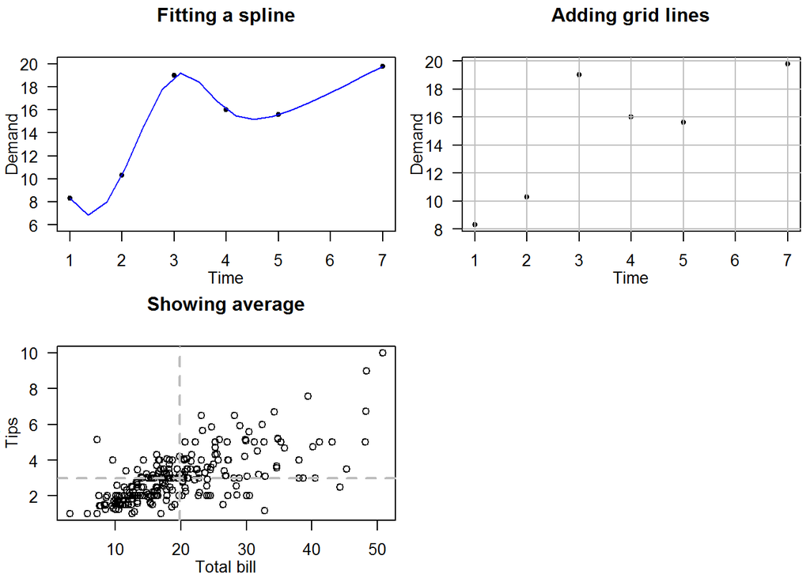

```r
op <- par("mfrow", "mar")
par(mfrow = c(2, 2), mar = c(rep.int(3, 3), 0.5))

# Add a spline (Interpolated line)
plot(BOD, pch = 20, ylim = c(6, 20), las = 1)
title(main = "Fitting a spline", xlab = "Time", ylab = "Demand", line = 1.9)
lines(spline(BOD), col = 4)

# Add grid lines (Aesthetics)
plot(BOD, pch = 20, las = 1)
title(main = "Adding grid lines", xlab = "Time", ylab = "Demand", line = 1.9)
abline(h = seq(8, 20, by = 2), v = 1:7, col = "grey")

# Show average
plot(tips[,1:2], las = 1)
title(main = "Showing average", xlab = "Total bill", ylab = "Tips", line = 1.9)
abline(h = mean(tips$tip), v = mean(tips$total_bill), lty = 2, col = 8, lwd = 2)

par(mfrow = op$mfrow, mar = op$mar)
```

## Generating and Annotating Mathematical Plots

Mathematical (and indeed other scientific) plots can be generated in R annotated with models and/or functions used to generate them. These functions or models are added to plots as “expressions” using a text annotating function.

Expressions are syntactically correct but unevaluated functions or commands. Syntactically correct means code is in R language and capable of being evaluated if run. Expressions are used to prevent evaluation like in this case we will use them to annotate plots but also they are not evaluated.

In R, expressions are created with “expression” function.

```r
# General code to be evaluated
1 + 1
## [1] 2
class(1 + 1)
## [1] "numeric"

# Passing code to "expression()" stops evaluation
expression(1 + 1)
## expression(1 + 1)
class(expression(1 + 1))
## [1] "expression"

# Evaluating an expression
eval(expression(1 + 1))
## [1] 2
```

Now let’s look at some examples of how expressions can be used to explain a plot.

For our first example we will construct a plot with a regression model `Cx = 156 + 19.7x` modeling relationship between costs and sales of cameras; our a domain will be `1 <= x <= 15`.

But before plotting, one key consideration we need to make are coordinates of the texts/expression. Specifically alignment (par(“adj”)), orientation (par(“srt”)), and position (par(“pos”)).

To add the model as expressions with characters, we will need to decompose it to three components; “Cx”, “=” and “156 + 19.7x” with the expectation that they will be plotted above the regression line. We shall then plot the domain at the bottom right of the plot.

In order to estimate x and y coordinates, we will call “strWidth” function to compute distances between each component.

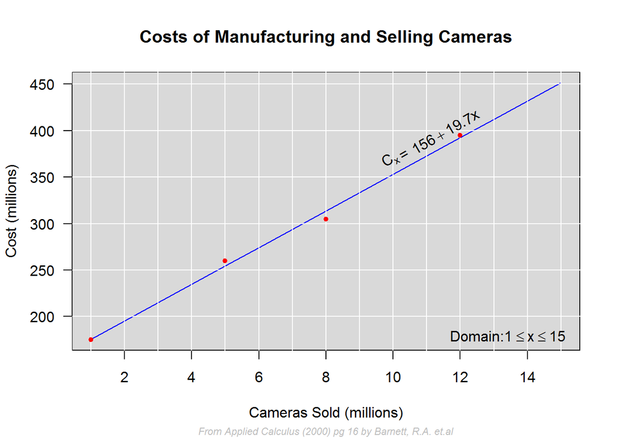

```r
# Constructing a plot
#---------------------
# Data for plotting
x1 <- c(1, 5, 8, 12)
Cx1 <- c(175, 260, 305, 395)

# A simple scatter plot (points added after grids)
plot(x1, Cx1, type = "n", main = "Costs of Manufacturing and Selling Cameras", xlab = "Cameras Sold (millions)", ylab = c("Cost (millions)"), xlim = c(1, 15), ylim = c(175, 452), las = 1, frame.plot = FALSE)
title(sub = "From Applied Calculus (2000) pg 16 by Barnett, R.A. et.al", cex.sub = 0.7, col.sub = "grey", font.sub = 3)

# Adding some aesthetics (background color for plot region)
rect(par("usr")[1], par("usr")[3], par("usr")[2], par("usr")[4], col = grey.colors(1, start = 0.85))

# Adding a regression line (pre-analysed function)
x2 <- 1:15
Cx2 <- 156 + 19.7 * x2
lines(x2, Cx2, col = 4)

# More aesthetics (grid lines)
abline(h = axTicks(2), v = 1:15, col = "white")

# Adding points last to avoid being plotted over by grid lines
points(x1, Cx1, pch = 20, col = 2)

# Annotating with expressions
#-----------------------------
# Components of regression model
expr <- expression(C[x])
str  <- "="
expr1  <- expression(156 + 19.7*x)


# Computing coordinates for each component of the expression
# Width of spaces in between text
empStr <- strwidth(" ")
# First component (Cx) will be centered around x = 10 (half of the text will be before and the other after 10)
width1 <- 10
# Second component ("=") will start about 0.9 after end of first component
width2 <- width1 + strwidth("Cx")/2 + strwidth("=")/2
# Third component (156 + 19.7x) will be about 1 (cex) from end of the second component
width3 <- width2 + strwidth("=")/2 + strwidth(expr1)/2
# Vector with combined widths
widths <- c(width1, width2, width3)

# Adding model as a text/expression
slope <- 19.7 + 10.3
text(x = widths, y = c(156 + 19.7 * widths), labels = c(expr, str, expr1), pos = 3, srt = slope)

# Computing coordinates for domain
str1  <- "Domain:"
expr2 <- expression(1 <= x)
expr3 <- expression(x <= 15)
domain <- c(str1, expr2, expr3)
width1 <- 12.5
width2 <- width1 + strwidth(str1)/2 + strwidth(expr2)/2
width3 <- width2 + strwidth(expr2)/2 + strwidth(expr3)/2 - strwidth("x")
# Annotating with domain
text(x = c(width1, width2, width3), y = par("usr")[3], labels = domain, pos = 3)
```

In our second example we look at how to add nonlinear functions to plots and annotate with formulas.

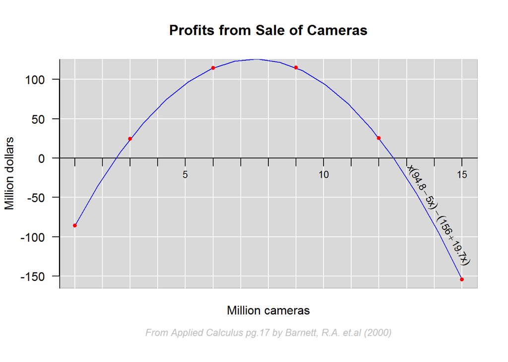

```r
# Data
x <- c(1, 3, 6, 9, 12, 15)
expr <- expression(Px = x * (94.8 - 5 * x) - (156 + 19.7 * x))
Px <- eval(expr)
cbind(x, round(Px))
##       x
## [1,]  1  -86
## [2,]  3   24
## [3,]  6  115
## [4,]  9  115
## [5,] 12   25
## [6,] 15 -155


# Plot suppressing points so they are not covered with grid lines, x label so that it is later position at line 1, and x axis which will be plotted at origin (x = 0, y = 0)
plot(x = x, y = Px, type = "n", main = "Profits from Sale of Cameras", xlab = "", ylab = "Million dollars", las = 1, frame.plot = FALSE, xaxt = "n")

# Annotating with subtitle and  x label
title(xlab = "Million cameras", line = 1)
title(sub = "From Applied Calculus pg.17 by Barnett, R.A. et.al (2000)", cex.sub = 0.8, font.sub = 3, col.sub = "grey",  line = 2.5)

# Adding background color
rect(par("usr")[1], par("usr")[3], par("usr")[2], par("usr")[4], col = grey.colors(1, start = 0.85), border = "grey")

# Adding grid lines (for that mathematical graphing effect)
abline(h = axTicks(2), v = 1:16, col = "white")

# Drawing axis lines
segments(x0 = 0, y0 = 0, x1 = par("usr")[2])
segments(x0 = par("usr")[1], y0 = par("usr")[3], y1 = par("usr")[4], lwd = 2)

# Drawing Tick marks
invisible(sapply(1:15, function(x) segments(x0 = x, y0 = 0, y1 = -10)))

# Adding axis labels
invisible(sapply(seq(5, 15, by = 5), function(i) text(x = i, y = -20, labels = i, cex = 0.8)))

# Fitting a curved (nonlinear) line with "spline"; interpolation line
lines(spline(x, Px), col = 4)

# Adding points last so that they are not masked by lines (grid and regression)
points(x, Px, pch = 20, col = 2)

# Annotating curve with formula used to produce it.
slope <- (Px[6] - Px[5])/ (x[6] - x[5])
text(x = 14, y = -85, labels = expr, pos = 3, srt = slope, cex = 0.8)
```

Finally, lets see how to construct a four quadrant Cartesian coordinate system.

In this example we will plot an exponential (y = 2^x) and a logarithmic (x = 2^y) function as well as a reflection line (y = x). Key consideration here are limits of both x and y axis given two data sets (exponential and logarithmic). Our interest is that both axis stretch as far as the maximum value of each data set.

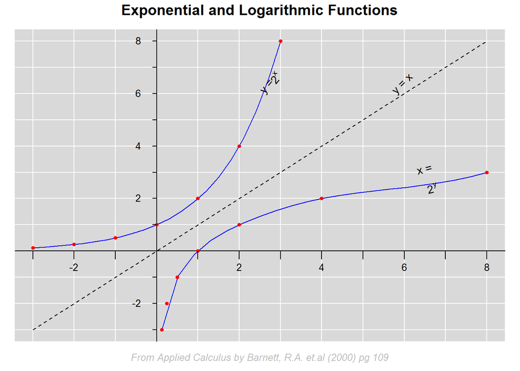

```r
# Exponent data
eX <- c(-3, -2, -1, 0, 1, 2, 3)
y_2x <- c(1/8, 1/4, 1/2, 1, 2, 4, 8)
# Logarithmic data
logX <- y_2x
y <- eX
cbind(eX, y_2x, logX, y)
##      eX  y_2x  logX  y
## [1,] -3 0.125 0.125 -3
## [2,] -2 0.250 0.250 -2
## [3,] -1 0.500 0.500 -1
## [4,]  0 1.000 1.000  0
## [5,]  1 2.000 2.000  1
## [6,]  2 4.000 4.000  2
## [7,]  3 8.000 8.000  3

# Determining limits of each data set
xlim1 <- range(eX)
ylim1 <- range(y_2x)
xlim2 <- range(logX)
ylim2 <- range(y)
xlim1; xlim2
## [1] -3  3
## [1] 0.125 8.000
ylim1; ylim2
## [1] 0.125 8.000
## [1] -3  3

# Constructing x and y limits based of maximum values of each data set
xlimts <- c(xlim1[1], xlim2[2])
ylimts <- c(ylim2[1], ylim1[2])
xlimts
## [1] -3  8
ylimts
## [1] -3  8

# Plotting
#----------

# Increase margins for plotting region
op <- par("mar")
par(mar = c(2, 1, 2, 1))

# Start a plot without points, annotation and axis
plot(x = xlimts, y = ylimts, type = "n", ann = FALSE, axes = FALSE)
title(main = "Exponential and Logarithmic Functions", cex = 1.5, line = 1)
title(sub = "From Applied Calculus by Barnett, R.A. et.al (2000) pg 109", cex.sub = 0.8, font.sub = 3, col.sub = "grey", line = 0.5)

# Add background color
rect(par("usr")[1], par("usr")[3], par("usr")[2], par("usr")[4], col = grey.colors(1, start = 0.85), border = "transparent")

# Add grid lines and lines for x and y axis
abline(h = -3:8, v = -3:8, col = "white")
abline(h = 0, v = 0)

# Adding reflection line
lines(x = c(-3, 8), y = c(-3, 8), lty = 2)

# Fit exponential and logarithmic functions
#-------------------------------------------
lines(spline(eX, y_2x), col = 4)
lines(spline(logX, y), col = 4)

# Add points
points(eX, y_2x, pch = 20, col = 2, cex = 0.9)
points(logX, y, pch = 20, col = 2, cex = 0.9)

# Draw tick marks
invisible(sapply(-3:8, function(x) segments(x0 = x, y0 = 0, y1 = -0.3)))
invisible(sapply(-3:8, function(x) segments(x0 = 0, y0 = x, x1 = -0.1)))

# Axis labels
invisible(sapply(seq(-2, 8, by = 2)[-2], function(x) text(x = x, y = -0.2, labels = x, pos = 1, cex = 0.8)))
invisible(sapply(seq(-2, 8, by = 2)[-2], function(x) text(x = -0.2, y = x, labels = x, pos = 2, cex = 0.8)))

# Annotating with mathematical functions
#----------------------------------------
radian <- 180/pi

slope <- (y_2x[7] - y_2x[6])/(eX[7] - eX[6])
angle <- atan(slope) * radian
text(x = c(2.4, 2.4 + strwidth(2.4)/2), y = c(6, ((2.4 + strwidth(2.4)/2 + empStr) - 2.4) + 6 + empStr), labels = c("y =", expression(y = 2 ^ x)), pos = 4, cex = 0.9, srt = 50)

slope <- (7 - 6)/(7 - 6)
angle <- atan(slope) * radian
text(x = 6, y = 6, labels = "y = x", pos = 3, cex = 0.9, srt = angle)

slope <- (y[7] - y[6])/(logX[7] - logX[6])
angle <- atan(slope) * radian
x1 <- 6.5
x2 <- x1 + strwidth("x =")/2
text(x = c(x1, x2), y = c((x1 * 2.5)/6, tan(angle)*(x2 - x1)), labels = c("x =", expression(2 ^ y)), pos = 3, cex = 0.9, srt = angle)
```

```r
# Return original parameter
par(mar = op)
```